# Assessing Impact of Post-Discharge Care Management on Hospital Readmissions

Author

Dave Childers

Published

May 21, 2026

**Note:** For readability, the code in this report is hidden by default. View any code section by clicking `>Code`.

```r
options(browser = function(url) invisible(NULL))
library(fs)
library(tidyverse)
library(arrow)
library(lme4)
library(broom)
library(gt)
library(scales)
library(brms)
theme_set(theme_bw())

prac <- read_parquet("practice-data.parquet")
pat <- read_parquet("patients.parquet")
hosp <- read_parquet("hospitalizations.parquet")
```

Github simulation [code](https://github.com/davechilders/post-discharge-intervention-analysis/blob/main/02-data-simulation-clean.R)

Github project [repo](https://github.com/davechilders/post-discharge-intervention-analysis)

## Background and Research Question

### Background

Under traditional fee-for-service reimbursement, a primary care practice has limited financial incentive to reduce hospitalizations among their patient population. Value-based care is a healthcare delivery and payment model that rewards providers for the quality and cost efficiency of care. For example, a primary care practice might enter a financial contract with an insurance company that involves reimbursing the practice for limiting the total healthcare expenditures for patients attributed to that practice.

Hospital admissions are a substantial component of total US healthcare spending. Reducing hospital readmissions during the 30-day post-discharge window is an opportunity to improve patient outcomes while reducing costs. Under fee-for-service, there is little incentive to invest in post-discharge care management to reduce readmission rates. However, value-based care models offer an opportunity for primary care providers to receive reimbursement for the savings obtained by reducing readmissions.

### Research Question

For a program designed to reduce the prevalence of hospital readmissions, it is important to assess the impact of that program in order to determine if the cost of the program justifies the reduction in healthcare spend and improvement in patient outcomes.

In this analysis, we use simulated data to demonstrate estimating the impact of a primary care practice incorporating post-discharge care management on the probability of all-cause hospital readmission during 30 days.

## Data Overview

### Simulated Data Description

For this analysis, we simulate data on practices, patients, and hospitalizations.

In a real-world scenario, we would expect the following:

- independent practices will have varying numbers of providers
- the number of patients per practice will vary based on the number of providers and the payer max (e.g. heavy medicare practices tend to have smaller patient panels)
- the timing of the intervention will vary across practices
- the rate of both hospitalization and readmission will vary by both patient and practice characteristics

There are also many factors beyond care management which may impact the probability of readmission, including:

- patient clinical factors such as primary diagnosis and comorbidities
- social drivers of heath including access to housing, social support, and transportation
- quality of primary care

The [simulated data](https://github.com/davechilders/post-discharge-intervention-analysis/blob/main/02-data-simulation-clean.R) for this analysis incorporates many of these characteristics.

### Treatment Assigment

For the purposes of this study, we assume that practices *selected* if and when to participate in the treatment of adoption care management. If practices were *assigned* to participate in the trial, then randomization would indicate there are no systematic differences among other pre-treatment variables that could be confounding. In the absence of randomization, it requires much stronger assumptions and specialized methods to ensure balance among the treatment and control practices.

### Practice Data

This is a glimpse of the simulated practice data.

```r
#summary(prac$intervention_start)

prac %>%
    slice(1:8) %>%
    gt() %>%
    cols_label(
        practice_id = "Prac ID",
        n_providers = "# Providers",
        n_medicare_pt = "# Medicare Pts",
        n_medicaid_pt = "# Medicaid Pts",
        n_private_pt = "# Private Pts",
        n_pt = "# Patients",
        has_intervention = "Case Mgmt",
        intervention_start = "Case Mgmt Start"
    ) %>%
    tab_header("Practice Level Data") %>%
    tab_footnote("This is the treatment variable", cells_column_labels(has_intervention)) %>%
    tab_footnote("The intervention start date varies by practice between '2023-01-01' and '2025-11-01'", cells_column_labels(intervention_start)) %>%
    fmt_number(starts_with("n_"), decimals = 0)
```

Practice Level Data

| Prac ID | # Providers | # Medicare Pts | # Medicaid Pts | # Private Pts | # Patients | Case Mgmt<sup>1</sup> | Case Mgmt Start<sup>2</sup> |
| --- | --- | --- | --- | --- | --- | --- | --- |
| 1 | 5 | 3,180 | 523 | 1,538 | 5,241 | 1 | 2023-06-01 |
| 2 | 6 | 2,253 | 236 | 5,599 | 8,088 | 1 | 2023-06-01 |
| 3 | 2 | 974 | 197 | 1,774 | 2,945 | 1 | 2023-09-01 |
| 4 | 5 | 709 | 974 | 7,942 | 9,625 | 0 | NA |
| 5 | 3 | 1,284 | 462 | 2,635 | 4,381 | 1 | 2025-10-01 |
| 6 | 3 | 412 | 347 | 4,840 | 5,599 | 1 | 2024-11-01 |
| 7 | 4 | 1,357 | 204 | 6,135 | 7,696 | 1 | 2025-08-01 |
| 8 | 1 | 202 | 18 | 1,410 | 1,630 | 0 | NA |

<sup>1</sup> This is the treatment variable  
<sup>2</sup> The intervention start date varies by practice between '2023-01-01' and '2025-11-01'

### Patient Data

```r
pat %>%
    group_by(insurance, esrd, ssdi) %>%
    sample_n(2) %>%
    ungroup() %>%
    gt() %>%
    tab_header("Simulated Patient Level Data") %>%
    cols_label(
        practice_id = "Prac ID",
        patient_id = "Patient ID",
        insurance = "Insurance",
        age = "Age",
        sex = "Sex",
        esrd = "ESRD",
        ssdi = "SSDI"
    ) %>%
    tab_footnote("Patient ID is nested within Practice ID", cells_column_labels(patient_id))
```

Simulated Patient Level Data

| Prac ID | Patient ID<sup>1</sup> | Insurance | Age | Sex | ESRD | SSDI |
| --- | --- | --- | --- | --- | --- | --- |
| 48 | 1429 | medicaid | 59 | M | 0 | 0 |
| 46 | 2755 | medicaid | 40 | F | 0 | 0 |
| 20 | 286 | medicare | 65 | M | 0 | 0 |
| 1 | 1171 | medicare | 74 | F | 0 | 0 |
| 48 | 1 | medicare | 61 | M | 0 | 1 |
| 44 | 1422 | medicare | 21 | M | 0 | 1 |
| 23 | 1581 | medicare | 34 | M | 1 | 0 |
| 31 | 28 | medicare | 72 | F | 1 | 0 |
| 49 | 2614 | private | 64 | F | 0 | 0 |
| 45 | 3630 | private | 20 | F | 0 | 0 |

<sup>1</sup> Patient ID is nested within Practice ID

### Hospitalization and Readmission Data

```r
hosp %>%
    slice(1:10) %>%
    gt() %>%
    tab_header("Simulated Hospitalization Level Data") %>%
    cols_label(
        practice_id = "Prac ID",
        patient_id = "Patient ID",
        hosp_date = "Hospitalization Date",
        readmit = "Readmission"
    ) %>%
    tab_footnote("Outcome of Interest: All-cause readmission within 30 days of discharge", cells_column_labels(readmit)) %>%
    tab_footnote("Two patients hospitalized on the same day may have different values for the treatment of interest (received post-discharge care management)",
    cells_column_labels(hosp_date))
```

Simulated Hospitalization Level Data

| Prac ID | Patient ID | Hospitalization Date<sup>1</sup> | Readmission<sup>2</sup> |
| --- | --- | --- | --- |
| 1 | 17 | 2024-07-01 | 0 |
| 1 | 18 | 2023-05-01 | 0 |
| 1 | 38 | 2022-09-01 | 0 |
| 1 | 104 | 2022-04-01 | 1 |
| 1 | 114 | 2023-06-01 | 0 |
| 1 | 125 | 2022-02-01 | 0 |
| 1 | 131 | 2025-01-01 | 0 |
| 1 | 138 | 2023-05-01 | 0 |
| 1 | 155 | 2025-06-01 | 0 |
| 1 | 159 | 2023-09-01 | 1 |

<sup>1</sup> Two patients hospitalized on the same day may have different values for the treatment of interest (received post-discharge care management)  
<sup>2</sup> Outcome of Interest: All-cause readmission within 30 days of discharge

### Other data issues not considered

Real-world data would likely have additional complications such as:

- ambiguity in attributing patients to practices
- many hospitalizations for the same patient within the study period
- dual insurance coverage or self-pay
- lags in the implementation of the intervention
- other relevant patient diagnoses

For simplicity, we don’t consider any of the above in this simulation.

### Compute Patient Outcome

This analysis joins the three simulated data sets together and has one row per patient hospitalization. Readmission is the binary outcome of interest. For simplicity, there is at most one record per patient.

```r
patient_outcome <- pat %>%
  left_join(prac, by = "practice_id") %>%
  left_join(hosp, by = c("practice_id", "patient_id")) %>%
  mutate(
    has_intervention_pt = case_when(
      has_intervention == 0 ~ 0,
      # if the patient is hospitalized before the practice adopts care managment,
      # the patient has a 0 for treatment even if the practice subsequently adopts care management
      intervention_start > hosp_date ~ 0,
      TRUE ~ 1
    ),
    hosp_date_years = as.integer(hosp_date - as.Date("2022-01-01")) / 365,
  )
```

## Analysis Dataset

```r
patient_outcome %>%
    select(practice_id, patient_id, insurance, age, sex, esrd, ssdi, hosp_date, has_intervention_pt, readmit) %>%
    filter(!is.na(hosp_date)) %>%
    group_by(readmit) %>%
    sample_n(3) %>%
    ungroup() %>%
    gt() %>%
    tab_header("Analysis Data Set", subtitle = "One row per patient for patients that have been hospitalized") %>%
    cols_label(
        practice_id = "Prac ID",
        patient_id = "Patient ID",
        insurance = "Insurance",
        age = "Age",
        sex = "Sex",
        esrd = "ESRD",
        ssdi = "SSDI",
        hosp_date = "Hospitalization Date",
        has_intervention_pt = "Case Management",
        readmit = "Readmission"
    ) %>%
    tab_footnote("Treatment of Interest", cells_column_labels(has_intervention_pt)) %>%
    tab_footnote("Outcome of Interest", cells_column_labels(readmit))
```

Analysis Data Set

One row per patient for patients that have been hospitalized

| Prac ID | Patient ID | Insurance | Age | Sex | ESRD | SSDI | Hospitalization Date | Case Management<sup>1</sup> | Readmission<sup>2</sup> |
| --- | --- | --- | --- | --- | --- | --- | --- | --- | --- |
| 4 | 8309 | private | 7 | M | 0 | 0 | 2024-08-01 | 0 | 0 |
| 13 | 5116 | private | 7 | F | 0 | 0 | 2025-06-01 | 1 | 0 |
| 57 | 1327 | medicare | 78 | M | 0 | 0 | 2025-04-01 | 1 | 0 |
| 23 | 862 | medicare | 82 | M | 0 | 0 | 2024-05-01 | 0 | 1 |
| 23 | 1275 | medicare | 73 | F | 0 | 0 | 2025-08-01 | 0 | 1 |
| 61 | 1096 | medicare | 74 | M | 0 | 0 | 2022-09-01 | 0 | 1 |

<sup>1</sup> Treatment of Interest  
<sup>2</sup> Outcome of Interest

## Exploratory Analysis

Before fitting a statistical model to estimate the effect of interest, we provide some data summaries and visualizations to understand the relationships among the features.

```r
# hospitalization rate
patient_outcome %>%
    count(is_hosp = !is.na(hosp_date)) %>%
    mutate(p = n / sum(n)) %>%
    gt() %>%
    tab_header(
        "Distribution of Hospitalization",
        subtitle = glue::glue("Among the {comma(nrow(patient_outcome))} patients in the study")
    ) %>%
    fmt_number(n, decimals = 0) %>%
    fmt_percent(p, decimals = 1) %>%
    cols_label(
        is_hosp = "Hospitalized?",
        n = "# Patients",
        p = "% Patients"
    ) %>%
    tab_footnote(
        "TRUE if a patient is hospitalized at least once from Jan 2022 through Dec 2025",
        cells_column_labels(is_hosp)
    )
```

Distribution of Hospitalization

Among the 420,344 patients in the study

| Hospitalized?<sup>1</sup> | # Patients | % Patients |
| --- | --- | --- |
| FALSE | 405,205 | 96.4% |
| TRUE | 15,139 | 3.6% |

<sup>1</sup> TRUE if a patient is hospitalized at least once from Jan 2022 through Dec 2025

```r
# readmission rate
patient_outcome %>%
    filter(!is.na(hosp_date)) %>%
    count(readmit) %>%
    mutate(p = n / sum(n)) %>%
    gt() %>%
    tab_header(
        "30-day readmission",
        subtitle = glue::glue("Among the {comma(nrow(patient_outcome %>% filter(!is.na(hosp_date))))} hospitalized in the study")
    ) %>%
    fmt_number(n, decimals = 0) %>%
    fmt_percent(p, decimals = 1) %>%
    cols_label(
        readmit = "Readmission?",
        n = "# Patients",
        p = "% Patients"
    ) %>%
    tab_footnote(
        "TRUE if a patient is readmitted within 30 days of discharge",
        cells_column_labels(readmit)
    )
```

30-day readmission

Among the 15,139 hospitalized in the study

| Readmission?<sup>1</sup> | # Patients | % Patients |
| --- | --- | --- |
| 0 | 13,271 | 87.7% |
| 1 | 1,868 | 12.3% |

<sup>1</sup> TRUE if a patient is readmitted within 30 days of discharge

This table shows the bivariate relationship between treatment (care management) and outcome (readmission). Patients receiving care management readmit at a lower rate.

```r
# readmission rate by treatment
patient_outcome %>%
    filter(!is.na(hosp_date)) %>%
    count(has_intervention_pt, readmit) %>%
    mutate(has_intervention_pt = factor(has_intervention_pt,
                                        levels = c(0, 1),
                                        labels = c("No Care Management", "Care Management"))) %>%
    group_by(has_intervention_pt) %>%
    mutate(p = n / sum(n)) %>%
    gt() %>%
    tab_header(
        "30-day readmission",
        subtitle = glue::glue("Among the {comma(nrow(patient_outcome %>% filter(!is.na(hosp_date))))} hospitalized in the study")
    ) %>%
    fmt_number(n, decimals = 0) %>%
    fmt_percent(p, decimals = 1) %>%
    cols_label(
        readmit = "Readmission?",
        n = "# Patients",
        p = "% Patients"
    ) %>%
    # tab_footnote(
    #     "Note: patients with care managment treatment have a lower rate of readmission",
    #     cells_column_labels(p)
    # ) %>%
    tab_style(
        style = cell_fill(color = "green"),
        locations = cells_body(
            columns = p,
            rows = (readmit == 1 & has_intervention_pt == "Care Management")
        )
    ) %>%
       tab_style(
        style = cell_fill(color = "yellow"),
        locations = cells_body(
            columns = p,
            rows = (readmit == 1 & has_intervention_pt == "No Care Management")
        )
    )
```

30-day readmission

Among the 15,139 hospitalized in the study

| Readmission? | # Patients | % Patients |
| --- | --- | --- |
| No Care Management |  |  |
| 0 | 9,267 | 86.5% |
| 1 | 1,449 | 13.5% |
| Care Management |  |  |
| 0 | 4,004 | 90.5% |
| 1 | 419 | 9.5% |

This plot shows the change in propensity to receive treatment, $P(T = 1)$, over time. The incremental nature of rolling out a care management intervention across practices means that more practices will have adopted the intervention by the end of the study period.

Two implications for modeling:

- we will only include years 2023-2025 in the model as there are not treatment cases during 2022
- we need to assess if time is related to $Y$ in addition to $T$ to determine if it is a confounder

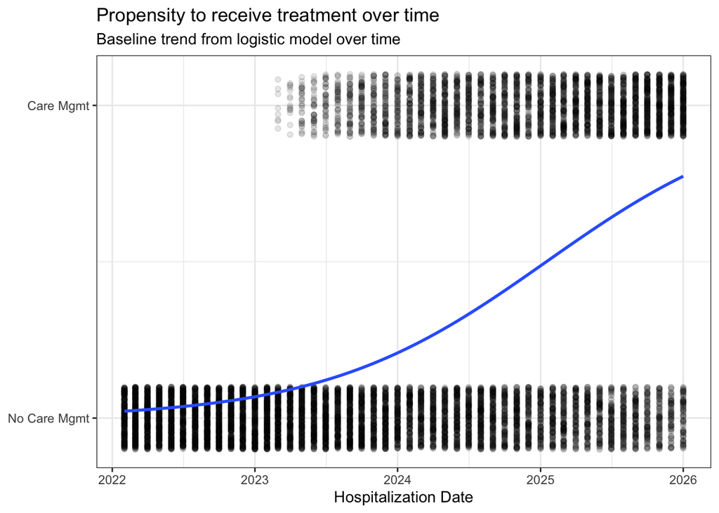

```r
# proportion of treated and untreated over time
patient_outcome %>%
    filter(!is.na(hosp_date)) %>%
    select(has_intervention_pt, hosp_date) %>%
    ggplot(aes(x = hosp_date, y = has_intervention_pt)) +
    geom_jitter(alpha = 0.1, width = 0, height = 0.1) +
    stat_smooth(method = "glm", method.args = list(family = binomial), se = FALSE) +
    scale_y_continuous(breaks = c(0, 1), labels = c("No Care Mgmt", "Care Mgmt")) +
    labs(
        title = "Propensity to receive treatment over time",
        subtitle = "Baseline trend from logistic model over time",
        x = "Hospitalization Date",
        y = NULL
    )
```

These plot shows baseline readmission rates over time. The first plot shows the trend for all patients. The second plot shows separate trends for treated and control patients.

The underlying decreasing trend indicates that time of hospitalization is a confounder. Time of hospitalization is related to both:

- $T$: the propensity to be in the treatment group increases with time due to the incremental rollout, and
- $Y$: the decreasing probability of readmission may be related to other macro-trends beyond care management

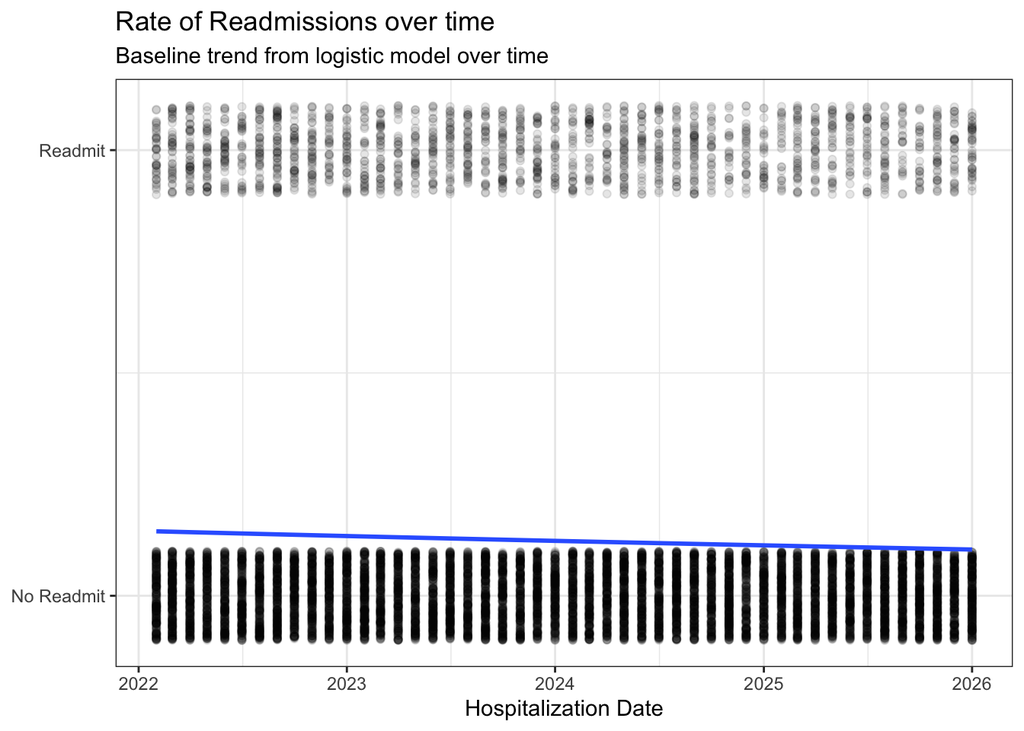

```r
# readmission rates over time
g_outcome_trend <- patient_outcome %>%
    filter(!is.na(hosp_date)) %>%
    ggplot(aes(x = hosp_date, y = readmit)) +
    geom_jitter(alpha = 0.1, width = 0, height = 0.1) +
    stat_smooth(method = "glm", method.args = list(family = binomial), se = FALSE) +
    scale_y_continuous(breaks = c(0, 1), labels = c("No Readmit", "Readmit")) +
    labs(
        title = "Rate of Readmissions over time",
        subtitle = "Baseline trend from logistic model over time",
        x = "Hospitalization Date",
        y = NULL
    )

g_outcome_trend
```

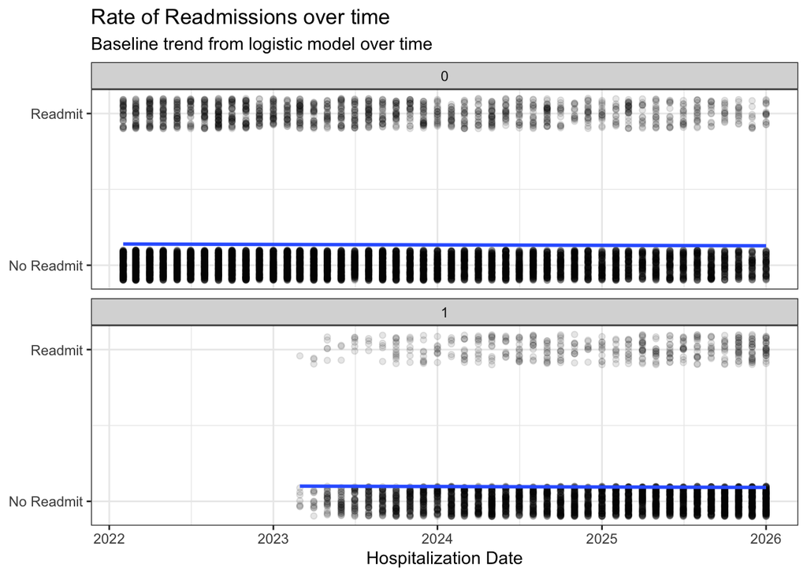

```r
g_outcome_trend + facet_wrap(~has_intervention_pt, ncol = 1)
```

Here, we check on the bivariate relationships between both ESRD status and insurance and the outcome.

```r
# hospitalization rate by insurance
patient_outcome %>%
    filter(!is.na(hosp_date)) %>%
    count(insurance, readmit) %>%
    group_by(insurance) %>%
    mutate(p = n / sum(n)) %>%
    ungroup() %>%
    gt() %>%
    tab_header("Readmission rate by insurance",
            subtitle = "Among Hospitalized Patients") %>%
    fmt_number(n, decimals = 0) %>%
    fmt_percent(p, decimals = 1)
```

Readmission rate by insurance

Among Hospitalized Patients

| insurance | readmit | n | p |
| --- | --- | --- | --- |
| medicaid | 0 | 1,083 | 90.2% |
| medicaid | 1 | 118 | 9.8% |
| medicare | 0 | 4,850 | 83.0% |
| medicare | 1 | 993 | 17.0% |
| private | 0 | 7,338 | 90.6% |
| private | 1 | 757 | 9.4% |

```r
# readmission rate by ESRD
patient_outcome %>%
    filter(!is.na(hosp_date)) %>%
    count(esrd, readmit) %>%
    group_by(esrd) %>%
    mutate(p = n / sum(n)) %>%
    ungroup() %>%
    gt() %>%
    tab_header("Readmission rate by ESRD status",
                subtitle = "Among Hospitalized Patients") %>%
    fmt_number(n, decimals = 0) %>%
    fmt_percent(p, decimals = 1)
```

Readmission rate by ESRD status

Among Hospitalized Patients

| esrd | readmit | n | p |
| --- | --- | --- | --- |
| 0 | 0 | 12,968 | 88.1% |
| 0 | 1 | 1,746 | 11.9% |
| 1 | 0 | 303 | 71.3% |
| 1 | 1 | 122 | 28.7% |

We saw that medicare patients have a higher rate of readmission. Aggregating to the practice level, we see that practices with a higher medicare mix also have higher readmission rates.

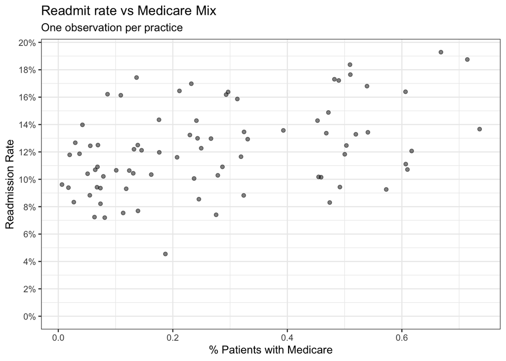

```r
# per practice: medicare mix vs readmit rate
medicare_outcome_df <- patient_outcome %>%
    group_by(practice_id) %>%
    summarise(
        medicare_mix = sum(insurance == "medicare") / n(),
        readmit_rate = sum(readmit[!is.na(hosp_date)]) / sum(!is.na(hosp_date))
    )

ggplot(medicare_outcome_df, aes(x = medicare_mix, y = readmit_rate)) +
  geom_point(alpha = 0.5) +
  labs(
    title = "Readmit rate vs Medicare Mix",
    subtitle = "One observation per practice",
    x = "% Patients with Medicare",
    y = "Readmission Rate"
  ) +
    expand_limits(y = 0) +
    scale_y_continuous(breaks = pretty_breaks(8), label = percent)
```

## Model

### Inclusion Criteria

- any patient hospitalized since 2023-01-01
- patient does not have ESRD diagnosis

### Model Considerations

- allow for baseline decreasing rate of readmissions over time
- allow for practice and patient level covariates
- allow for variation among practices beyond what is captured in practice-level covariates
- accomodate the hierarchical dependency that arises from patients being grouped within practices

```r
model_data <- patient_outcome %>%
    filter(
        !is.na(hosp_date),
        hosp_date >= as.Date("2023-01-01"),
        esrd == 0
        )

model_data %>%
    count(has_intervention_pt, readmit) %>%
    mutate(p = n / sum(n)) %>%
    gt() %>%
    tab_header(
        "Sample sizes for models",
        subtitle = "Includes hospitalized patients meeting inclusion criteria"
    ) %>%
    fmt_number(n, decimals = 0) %>%
    fmt_percent(p, decimals = 1) %>%
    cols_label(
        has_intervention_pt = "Treated (T)",
        readmit = "Readmission (Y)",
        n = "# Patients",
        p = "% of Patients"
    )
```

Sample sizes for models

Includes hospitalized patients meeting inclusion criteria

| Treated (T) | Readmission (Y) | # Patients | % of Patients |
| --- | --- | --- | --- |
| 0 | 0 | 6,068 | 53.9% |
| 0 | 1 | 878 | 7.8% |
| 1 | 0 | 3,914 | 34.8% |
| 1 | 1 | 393 | 3.5% |

### Generalized Linear Mixed Model

We fit a generalized linear mixed model that models the probability of readmission for individual $i$ in practice $j$. This is an extension of a generalized linear model (with logit link) that allows for random practice-level effects.

$$P(Y_{ij} = 1) = logit^{-1}(\alpha_j + \beta_1 T_i + \beta_2 X_{2i} + \beta_3 X_{3i} + \beta_4 X_{4i} + \beta_5 X_{5i})$$

$$\alpha_j \sim N(0, \sigma^2_j)$$

- $i$ indexes the patient
- $j$ indexes the practice
- $\alpha_j$ is the random effect for practice $j$
- $T$ is the treatment of interest
- $X_2$ is a time covariate (time since beginning of study)
- $X_3$ is age
- $X_4$ is sex
- $X_5$ is ssdi status

There are several approaches to fit this model. We could:

- fit an approximateion to the marginal log-likelihood using `lme4::glmer()`
- fit a fully Bayesian model using `brms()`
- use generalized estimating equations instead of a multilevel

Here, we choose `glmer()` but other options are reasonable.

## Frequentist Results

```r
m2 <- glmer(
  readmit ~ (1 | practice_id) + has_intervention_pt + hosp_date_years + age + sex + ssdi,
  family = binomial,
  data = model_data
)

# other options: profile, boot
m2_confint <- confint(m2, method = "Wald") %>%
    as_tibble(rownames = "covariate") %>%
    rename(
        lower95 = `2.5 %`,
        upper95 = `97.5 %`
    )

m2_coeff <- summary(m2)$coefficients %>%
    as_tibble(rownames = "covariate") %>%
    rename(se = `Std. Error`)

m2_results <- m2_coeff %>% inner_join(m2_confint, by = "covariate") %>%
    select(covariate, Estimate, se, lower95, upper95) %>%
    mutate(
        odds_ratio = exp(Estimate),
        lower95_odds = exp(lower95),
        upper95_odds = exp(upper95)
    ) %>%
    select(covariate, odds_ratio, lower95_odds, upper95_odds) %>%
     mutate(covariate = recode_values(covariate,
        "(Intercept)"           ~ "Intercept",
        "has_intervention_pt" ~ "Treatment",
        "hosp_date_years"      ~ "Years from study beginning",
        "age"                 ~ "Age",
        "sexM"                ~ "Male Indicator",
        "ssdi"                ~ "SSDI Status"
        ))

gt(m2_results) %>%
    fmt_number(c(odds_ratio, lower95_odds, upper95_odds), decimals = 3) %>%
    cols_label(
        covariate = "Covariate",
        odds_ratio = "Odds Ratio",
        lower95_odds = "Lower 95% CI",
        upper95_odds = "Upper 95% CI"
    ) %>%
    tab_style(
        style = cell_fill(color = "green"),
        locations = cells_body(
            columns = odds_ratio,
            rows = (covariate == "Treatment")
        )
    ) %>%
    tab_footnote("Primary Effect of Interest",
    cells_body(
            columns = odds_ratio,
            rows = (covariate == "Treatment")
        )
     ) %>%
    tab_footnote(
        "CIs produced via Wald method for simplicity",
        cells_column_labels(c(lower95_odds, upper95_odds))
        ) %>%
    tab_footnote(
        "Produced by exponentiating the raw coefficients",
        cells_column_labels(odds_ratio)
    )
```

| Covariate | Odds Ratio<sup>1</sup> | Lower 95% CI<sup>2</sup> | Upper 95% CI<sup>2</sup> |
| --- | --- | --- | --- |
| Intercept | 0.069 | 0.054 | 0.087 |
| Treatment | <sup>3</sup> 0.699 | 0.602 | 0.811 |
| Years from study beginning | 0.989 | 0.920 | 1.064 |
| Age | 1.015 | 1.012 | 1.017 |
| Male Indicator | 0.958 | 0.851 | 1.078 |
| SSDI Status | 1.803 | 1.469 | 2.214 |

<sup>1</sup> Produced by exponentiating the raw coefficients  
<sup>2</sup> CIs produced via Wald method for simplicity  
<sup>3</sup> Primary Effect of Interest

## Bayesian Results

The results of the bayesian analysis obtained via brms are consistent with the frequentist likelihood-based approach using `lmer4::glmer()`.

```r
mbayes <- brm(
  readmit ~ (1 | practice_id) + has_intervention_pt + hosp_date_years + age + sex + ssdi,
  family = bernoulli(link = "logit"),
  data = model_data,
  prior = c(
    prior(normal(0, 2.5), class = b),
    prior(normal(0, 2.5), class = Intercept),
    prior(exponential(1),  class = sd)
  ),
  chains = 4,
  iter = 2000,       # 1000 warmup + 1000 sampling per chain by default
  warmup = 1000,
  cores = 4,
  seed = 42
)

# posterior predictive check of mean readmission rate
#pp_check(mbayes, type = "stat", stat = "mean")


fixef_results <- fixef(mbayes) %>%
    as_tibble(rownames = "covariate") %>%
    mutate(
        odds_ratio = exp(Estimate),
        lower95_odds = exp(`Q2.5`),
        upper95_odds = exp(`Q97.5`)
    ) %>%
    select(covariate, odds_ratio, lower95_odds, upper95_odds) %>%
     mutate(covariate = recode_values(covariate,
        "Intercept"           ~ "Intercept",
        "has_intervention_pt" ~ "Treatment",
        "hosp_date_years"      ~ "Years from study beginning",
        "age"                 ~ "Age",
        "sexM"                ~ "Male Indicator",
        "ssdi"                ~ "SSDI Status"
        ))

gt(fixef_results) %>%
    tab_header("Fixed Effects from Bayesian Model",
    subtitle = "Model fit using brms interface to Stan") %>%
    fmt_number(c(odds_ratio, lower95_odds, upper95_odds), decimals = 3) %>%
    cols_label(
        covariate = "Covariate",
        odds_ratio = "Odds Ratio",
        lower95_odds = "Lower 95% CI",
        upper95_odds = "Upper 95% CI"
    ) %>%
    tab_style(
        style = cell_fill(color = "green"),
        locations = cells_body(
            columns = odds_ratio,
            rows = (covariate == "Treatment")
        )
    ) %>%
    tab_footnote("Primary Effect of Interest",
    cells_body(
            columns = odds_ratio,
            rows = (covariate == "Treatment")
        )
     ) %>%
    tab_footnote(
        "Posterior Credible Intervals",
        cells_column_labels(c(lower95_odds, upper95_odds))
        ) %>%
    tab_footnote(
        "Produced by exponentiating the raw coefficients",
        cells_column_labels(odds_ratio)
    )
```

Fixed Effects from Bayesian Model

Model fit using brms interface to Stan

| Covariate | Odds Ratio<sup>1</sup> | Lower 95% CI<sup>2</sup> | Upper 95% CI<sup>2</sup> |
| --- | --- | --- | --- |
| Intercept | 0.069 | 0.053 | 0.087 |
| Treatment | <sup>3</sup> 0.698 | 0.598 | 0.811 |
| Years from study beginning | 0.989 | 0.916 | 1.070 |
| Age | 1.015 | 1.012 | 1.017 |
| Male Indicator | 0.957 | 0.848 | 1.075 |
| SSDI Status | 1.795 | 1.451 | 2.205 |

<sup>1</sup> Produced by exponentiating the raw coefficients  
<sup>2</sup> Posterior Credible Intervals  
<sup>3</sup> Primary Effect of Interest

## Conclusion

In this simulation, post-discharge care management is associated with a 30% reduced odds of readmission. Is this effect causal? For causal inference, we would need to assume ignorability of the treatment assignment. Equivalently, we would need to assume all confounding covariates were included. This study was simulated, so we are certain that all confounding covariates have been included. However, in practice, there are likely other covariates impacting treatment selection and readmission. Therefore, we would want to employ other methods such as matching in order to make causal claims.